# group_08 – Climate Gazette

*A story created @ Visualising Climate 2026, Bologna*

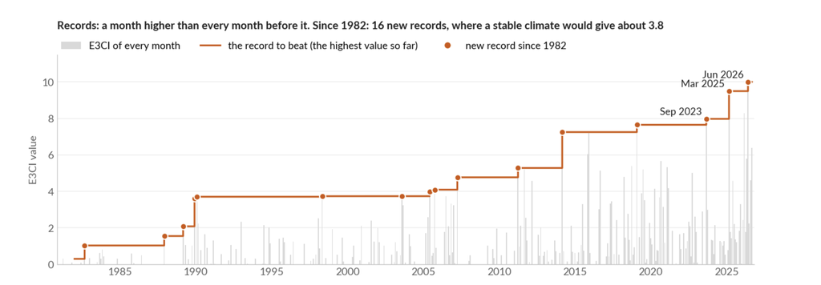

### How to read the E3CI

- For every **month**, **place** and **component** (heat, cold, drought, rain, wind, hail, fire), the E3CI compares that month with the **same month in 1981–2010**: 0 = a normal month, 1 = one standard deviation above normal.
- **Values above 1 are extreme**, in three classes: 1–2, 2–3, above 3 (the darker the colour, the more extreme).
- Because every month is compared with itself, an extreme in winter or autumn means unusual *for that season*. For example, a heat E3CI of 1.2 in July and of 2.5 in January does not mean that January was hotter than July. It means that January was much further from what is usual for January than July was from what is usual for July.

*Data: [E3CI – European Extreme Events Climate Index](https://www.climateindex.eu), from the Copernicus [ERA5 reanalysis](https://cds.climate.copernicus.eu/datasets/reanalysis-era5-single-levels?tab=overview).*

## An overview of extreme weather events in Europe from 1981 to the present day

### Is Europe getting more extreme?

A look at every extreme weather event of E3CI.

[figure not shown]

Extreme weather is becoming the new normal. As we can see here in Belgium. A country known by they green landscape, fires are now a concern.

### When in the year?

Comparison of two periods: 1981-2010 vs 2011-2026, divided by seasons.

[figure not shown]

## Compare countries in Europe: who is hit the hardest over the years?

[figure not shown]

But we are starting to see that is not a trend in the south and northern countries also reach extreme whether conditions

### One map per year: Europe trends at a glance

[figure not shown]

## Zoom in

### The barcode of extremes

[figure not shown]

### Comparison between two extreme weather components

[figure not shown]

### Month by month, and the records

[figure not shown]

### Let’s explore a specific extreme weather event closer

[figure not shown]

Another example are the floods in Belgium and Germany in 2021